# GLMMs: worked examples

2014-05-06 12:43:33

These are worked examples for a forthcoming book chapter on mixed models (in *Ecological Statistics: Contemporary Theory and Application*, editors Negrete, Sosa, and Fox).

It may move or be renamed eventually, but for right now the source (`.rmd`) file and data files are available from `http://www.math.mcmaster.ca/bolker/R/misc/foxchapter`:

- [source](http://www.math.mcmaster.ca/bolker/R/misc/foxchapter/bolker_chap.rmd)
- [auxiliary file for horizontal line ranges in ggplot](http://www.math.mcmaster.ca/bolker/R/misc/foxchapter/geom-linerangeh.R)
- [tundra data](http://www.math.mcmaster.ca/bolker/R/misc/foxchapter/tundra.csv)
- [Culcita data](http://www.math.mcmaster.ca/bolker/R/misc/foxchapter/culcita.RData)
- [gopher tortoise data](http://www.math.mcmaster.ca/bolker/R/misc/foxchapter/gopherdat2.RData)
- [tick data](http://www.math.mcmaster.ca/bolker/R/misc/foxchapter/Elston2001_tickdata.txt)

There's a *lot* of material here, and I have erred slightly on the side of including things, and on the side of compact rather than elementary code.

I use a very large set of packages in this example, because I am trying out a wide range of approaches. You should whittle these down to just the ones you need for any given analysis …

```r
## primary GLMM-fitting packages:
library(lme4)
library(glmmADMB)
library(MCMCglmm)
library(blme)
library(MASS)          ## for glmmPQL
library(nlme)          ## for intervals(), tundra example
## auxiliary
library(ggplot2)       ## for pretty plots generally
## ggplot customization:
theme_set(theme_bw())
library(grid)          ## for unit()
zmargin <- theme(panel.margin=unit(0,"lines")) ## to squash facets together ...
library(scales)        ## for squish()
library(gridExtra)     ## for grid.arrange()
library(proto)         ## for horizontal line range plot
source("geom-linerangeh.R")  ## for horizontal line ranges
library(coefplot2) ## coefficient plots
library(coda)      ## MCMC diagnostics
library(aods3)     ## overdispersion diagnostics
library(scapeMCMC) ## pretty plots from MCMC fits
library(bbmle)     ## AICtab
library(pbkrtest)  ## parametric bootstrap
library(Hmisc)
## library(plotrix)  ## for plotCI
## library(emdbook)  ## for curve3d()
## for general-purpose reshaping and data manipulation:
library(reshape2)
library(plyr)
library(numDeriv)
```

Package versions used (core packages only):

```
##      lme4  glmmADMB  MCMCglmm      blme  pbkrtest coefplot2      coda
##     1.1.7     0.7.7      2.18     1.0.2     0.3.8   0.1.3.2    0.16.1
##     aods3     bbmle
##     0.4.1    1.0.16
```

## Tundra carbon

These data were originally analyzed in Belshe *et al.* 2013, “Tundra ecosystems observed to be CO<sup>2</sup> sources due to differential amplification of the carbon cycle”, *Ecology Letters* 16 (10), 1307-1315 (doi: 10.1111/ele.12164).

### Data exploration

```r
mc1 <- read.csv("tundra.csv",na.strings=c("-","NA"))
```

A first look at the data, plotting net ecosystem exchange during the growing season (`GS.NEE`) against year, using colour to distinguish sites, and superimposing a separate linear regresssion (with confidence bands) per site:

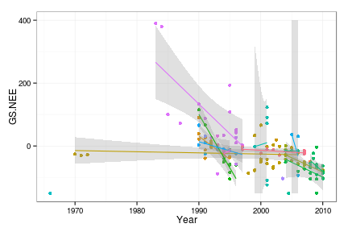

```r
ggplot(mc1,aes(x=Year,y=GS.NEE,colour=Site))+geom_point()+
    geom_smooth(method="lm",alpha=0.3)+
    ## oob=squish retains the (truncated) confidence bands;
    ## otherwise bands that went outside the limits would disappear
    ## (requires the 'scales' package be loaded)
    scale_y_continuous(limits=c(-150,400),oob=squish)+
    scale_colour_discrete(guide="none") ## suppress legend
```

We have suppressed the legend for the colours, because there are a lot of sites and their names will not be particularly meaningful to people who are not tundra biologists. There is lots of variability among sites, both in the trend and in the uncertainty of the trend. The uncertainty is caused in part by noisiness of the data, and part by sparsity/shortness of the time series for individual sites.

In some cases there were multiple observations per site in a single year. We could have handled this by adding a year-within-site random variable, but it proved to be easier to aggregate these cases by calculating the mean, and account for the different amount of sampling by weighting site-year combinations according to the number of samples.

The following (rather complicated) function aggregates the data; in the course of our analysis we ended up needing to aggregate several different response variables according to several different sets of grouping variables. We re-centred the year to have year=0 at the beginning of the observation period.

```r
aggfun <- function(dat,agg=c("Year","Site"),response="Winter.adj",
                   baseYear=min(mc1$Year)) {
    ## select only site, year, and response
    sub1 <- na.omit(dat[,c("Site","Year",response)])
    ## compute means of non-aggregation variables
    agg1 <- aggregate(sub1[!names(sub1) %in% agg],by=sub1[agg],FUN=mean)
    ## compute sample size of non-aggregation variables
    aggn <- aggregate(sub1[response],by=sub1[agg],FUN=length)
    names(aggn)[ncol(aggn)] <- "n"   ## assumes response is last column
    ## put mean and sample size together
    agg2 <- merge(agg1,aggn)
    ## recompute centred year
    agg2$cYear <- agg2$Year - baseYear
    agg2
}
mc2 <- aggfun(mc1,response="GS.NEE")
## center year at the mean rather than the date of
## the first observation:
mc2B <- aggfun(mc1,response="GS.NEE",baseYear=mean(mc1$Year))
```

The aggregated data show a similar picture:

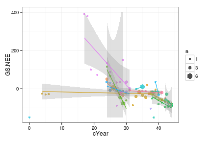

```r
ggplot(mc2,aes(x=cYear,y=GS.NEE,colour=Site))+
    geom_point(aes(size=n),alpha=0.7)+
    geom_smooth(method="lm",alpha=0.3,aes(weight=n))+
    scale_y_continuous(limits=c(-150,400),oob=squish)+
    scale_colour_discrete(guide="none")+
    scale_size_continuous(range=c(2,5),breaks=c(1,3,6))
```

### Fitting

We use `nlme::lme` because at present it is the only *easy* way to allow for temporal autocorrelation in a LMM in R.

- we use `corCAR1`, which implements a continuous-time first-order autocorrelation model (i.e. autocorrelation declines exponentially with time), because we have missing values in the data. The more standard discrete-time autocorrelation models (`lme` offers `corAR1` for a first-order model and `corARMA` for a more general model) don't work with missing data.
- The `weights=varFixed(~I(1/n))` specifies that the residual variance for each (aggregated) data point is inversely proportional to the number of samples.
- The `control` argument lets the model try more iterations (otherwise we get an error).

```r
cmod_lme <- lme(GS.NEE ~ cYear,
                data=mc2, method="REML",
                random = ~ 1 + cYear | Site,
                correlation=corCAR1(form=~cYear|Site),
                weights=varFixed(~I(1/n)),
                control=list(maxIter=10000, niterEM=10000))
```

Model summary:

```r
summary(cmod_lme)
```

```
## Linear mixed-effects model fit by REML
##  Data: mc2
##     AIC   BIC logLik
##   879.8 896.4 -432.9
##
## Random effects:
##  Formula: ~1 + cYear | Site
##  Structure: General positive-definite, Log-Cholesky parametrization
##             StdDev  Corr
## (Intercept) 147.904 (Intr)
## cYear         4.232 -1
## Residual     60.063
##
## Correlation Structure: Continuous AR(1)
##  Formula: ~cYear | Site
##  Parameter estimate(s):
##    Phi
## 0.4039
## Variance function:
##  Structure: fixed weights
##  Formula: ~I(1/n)
## Fixed effects: GS.NEE ~ cYear
##              Value Std.Error DF t-value p-value
## (Intercept) 108.89     48.02 57   2.267  0.0272
## cYear        -3.85      1.37 57  -2.802  0.0069
##  Correlation:
##       (Intr)
## cYear -0.987
##
## Standardized Within-Group Residuals:
##     Min      Q1     Med      Q3     Max
## -2.7596 -0.4218 -0.1201  0.2685  3.0855
##
## Number of Observations: 82
## Number of Groups: 24
```

The results generally look sensible: the only warning sign is that the among-site variation in baseline NEE (`(Intercept)`) and the among-site variation in slope are perfectly correlated (i.e., the `-1` term in the `Corr` column under `Random effects`). We weren't happy with this, but we kept the full random effects model anyway. The alternative, dropping the random effect of year, seemed unacceptable in our case. Recentring the data at the mean year (\( \approx \) 1997) improves things slightly:

```r
cmod2_lme <- update(cmod_lme,data=mc2B)
```

`VarCorr()` or `summary()` show that the intercept and slope random effects are still very strongly, but not perfectly, correlated (\( \rho=0.973 \)); the fixed-effect intercept is very different (of course), and the year effect is almost identical, but its standard error is larger (so its \( p \)-value doubles).

```
##              Value Std.Error DF t-value p-value
## (Intercept) -17.42      7.77 57   -2.24   0.029 *
## cYear        -3.84      1.51 57   -2.55   0.014 *
## ---
## Signif. codes:  0 '***' 0.001 '**' 0.01 '*' 0.05 '.' 0.1 ' ' 1
```

We can also fit the model with `lmer` from the `lme4` package: it's faster and allows for crossed random effects (neither of which really matters here), but unfortunately it can't incorporate temporal autocorrelation in the model:

```r
cmod_lmer <- lmer(GS.NEE ~ cYear + (1+cYear|Site),
                data=mc2B, REML=TRUE,
                weights=n)
summary(cmod_lmer)
```

```
## Linear mixed model fit by REML ['lmerMod']
## Formula: GS.NEE ~ cYear + (1 + cYear | Site)
##    Data: mc2B
## Weights: n
##
## REML criterion at convergence: 874.2
##
## Scaled residuals:
##     Min      1Q  Median      3Q     Max
## -2.9021 -0.3504 -0.0797  0.3015  2.9315
##
## Random effects:
##  Groups   Name        Variance Std.Dev. Corr
##  Site     (Intercept)  116.0   10.77
##           cYear         19.9    4.47    -1.00
##  Residual             3355.3   57.93
## Number of obs: 82, groups:  Site, 24
##
## Fixed effects:
##             Estimate Std. Error t value
## (Intercept)   -16.30       7.34   -2.22
## cYear          -3.75       1.34   -2.79
##
## Correlation of Fixed Effects:
##       (Intr)
## cYear -0.417
```

Note that `weights` here are specified as `n` rather than `1/n` (`varFixed()` in the `lme` call specifies the variance, rather than the actual weights of different observations)

The results are not *too* different – the `cYear` fixed-effect slope is slightly smaller than for the `lme` fit (-3.75 vs. -3.84 (g C m<sup>2</sup> /year/season)/year), but the standard error is smaller, so the \( t \)-statistic is similar (-2.79 vs. -2.55).

We have to admit that the model we are using is just a little bit more complex than the data can easily handle, and especially that Toolik is quite different from the other sites … making the estimates somewhat unstable.

### Diagnostics

Here are the default residuals-vs.-fitted plot; the scale-location plot (\( \sqrt{|\textrm{residual}|} \) vs. fitted); a plot of the residuals as a function of year; and the Q-Q plot.

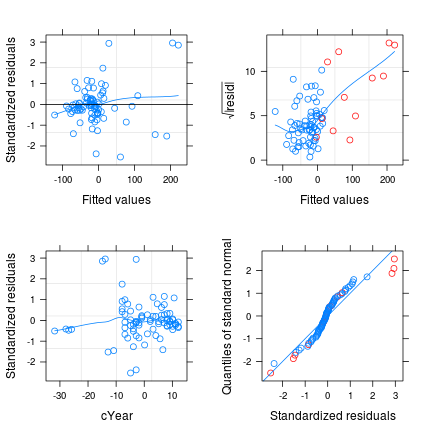

```r
colvec <- c("#ff1111","#007eff") ## second colour matches lattice default
grid.arrange(plot(cmod2_lme,type=c("p","smooth")),
             plot(cmod2_lme,sqrt(abs(resid(.)))~fitted(.),
                  col=ifelse(mc2$Site=="Toolik, AK",colvec[1],colvec[2]),
                  type=c("p","smooth"),ylab=expression(sqrt(abs(resid)))),
                                       ## "sqrt(abs(resid(x)))"),
             plot(cmod2_lme,resid(.,type="pearson")~cYear,
                  type=c("p","smooth")),
             qqnorm(cmod2_lme,abline=c(0,1),
                    col=ifelse(mc2$Site=="Toolik, AK",colvec[1],colvec[2])))
```

The diagnostics look OK – mostly.

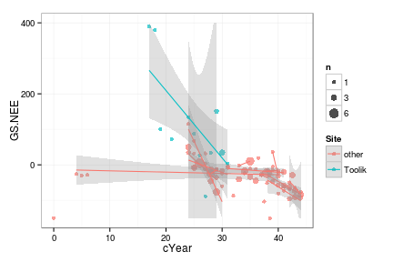

```r
ggplot(mc2,aes(x=cYear,y=GS.NEE,colour=(Site=="Toolik, AK")))+
    geom_point(aes(size=n),alpha=0.7)+
    geom_smooth(method="lm",alpha=0.3,aes(weight=n,group=Site))+
    scale_colour_discrete(name="Site",breaks=0:1,labels=c("other","Toolik"))+
    scale_y_continuous(limits=c(-150,400),oob=squish)+
    scale_size_continuous(range=c(2,5),breaks=c(1,3,6))
```

We should also check whether our model has dealt with temporal autocorrelation properly. One potential trap when diagnosing autocorrelation in `lme` models is that the `ACF()` function by default uses a form of the residuals that do not correct for autocorrelation, *even when there is a correlation term specified in the fitted model*: you have to use `resType="normalized"` to get autocorrelation-corrected residuals, as shown in the right-hand plot below:

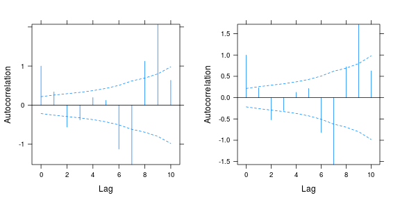

```r
grid.arrange(plot(ACF(cmod2_lme),alpha=0.05),
             plot(ACF(cmod2_lme,resType="normalized"),alpha=0.05),
             nrow=1)
```

The autocorrelation term in the model has successfully corrected for the autocorrelation at lag 1, but there are some large anomalies for longer time lags. These are somewhat worrisome, but autocorrelation estimates this large (absolute value >1) probably represent other anomalies in the data, rather than an actual signal of autocorrelation.

We can try refitting the model without the Toolik data. As it turns out we run into convergence problems and have to drop the autocorrelation structure from the model.

```r
cmod3_lme <- update(cmod2_lme,
                    data=subset(mc2,Site!="Toolik, AK"),
                    correlation=NULL)
plot(ACF(cmod3_lme),alpha=0.05) ## not shown, but looks fine
```

We are again stuck between what the data might tell us to do (throw out the Toolik data), and what we want to do as biologists (incorporate all the data). At least the results (the slope of NEE with respect to time) are not too much different when we fit the model without the Toolik data (the slope is actually steeper, although noisier): the coefficient table from `summary(cmod3_lme)` looks like this:

```
##              Value Std.Error DF t-value p-value
## (Intercept) 109.02     50.16 46    2.17   0.035 *
## cYear        -4.42      1.80 46   -2.46   0.018 *
## ---
## Signif. codes:  0 '***' 0.001 '**' 0.01 '*' 0.05 '.' 0.1 ' ' 1
```

What about the estimated random effects (conditional modes)? They are easy to extract, using the `ranef()` method, which is the same way you would do it with `lme4` or `glmmADMB`. Plotting them takes a little bit more effort – the default plot produced by the `nlme` package is OK, but (1) it doesn't plot the random effects in sorted order (which is a good default); (2) it doesn't produce standard errors; (3) it makes it a bit hard if we want to plot only one set of random effects (in this case, since `lme` has estimated the among-site variance in intercept to be very close to zero, it's not really worth plotting the intercept random effects).

```r
rr <- ranef(cmod2_lme)
rr.order <- rr[order(rr$cYear),] ## order by RE slope value
```

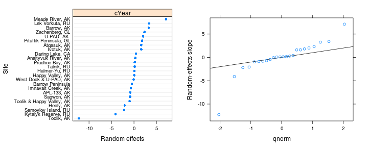

We can more easily plot the random effects for the `lmer` fit (we also get confidence intervals without too much fuss):

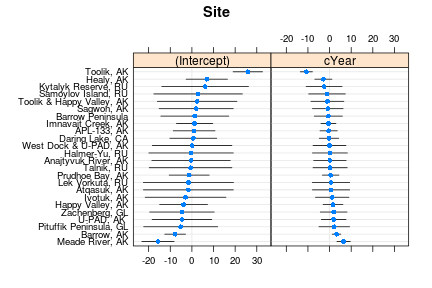

```r
dotplot(ranef(cmod_lmer,condVar=TRUE),
          lattice.options=list(layout=c(1,2)))
```

- In contrast to the `lme` fit, the `lmer` fit gives a non-negligible estimate for the among-site standard deviation.
- You can use `qqmath()` instead of `dotplot()` to get Q-Q plots of the conditional modes.
- Toolik still stands out as an outlier.